# 75.31 - Teoría del Lenguaje - Análisis del lenguaje R

Grupo 8

Colombo, Juan Ignacio - 103471

Janeiro, Ignacio - 103550

Ramos, Federico Andrés - 101640

Suarez, Martín Andrés - 101540

[figure not shown]

# Origen

R fue creado por Ross Ihaka y Robert Gentleman en la universidad de Auckland en 1991 y surge de la necesidad de encontrar una nueva forma de enseñar estadistica a alumnos de su facultad. El lenguaje fue anunciado en 1993 y luego, en 1995 usaron una licencia GNU, convirtiendo a R en software gratuito. Finalmente en el año 2000 se lanzó la version beta estable.

El lenguaje se basó en una implementacion de dos lenguajes ya existentes, siendo estos S y Scheme. Debido a su similitud con S y el hecho de que sea compatible con cualquier sistema operativo facilito su migracion y su aumento de popularidad.

# Para que sirve R

R es un lenguaje de programación cuyo uso está mayormente orientado a las estadísticas, debido a la gran cantidad de herramientas que posee, además de que se creo como herramienta para enseñar estadística. R es un lenguaje que cuenta con más de 10.000 paquetes en su repositorio CRAN. Algunos de estos paquetes, como por ejemplo `readr` facilitan trabajar con grandes cantidades de información desordenada, permitiendo ordenar y estructurar los datos para una mejor comprension de los mismos. Además R tiene una gran capacidad gráfica, permitiendonos visualizar toda la información de manera sencilla y con gran detalle utilizando librerias como `ggplot2` y `plotly`.

## ¿Por qué no usar R?

- No es un lenguaje muy eficiente. No es demasiado rápido y usa bastante memoria.
- Al ser muy usado en Machine Learning mucho del código que uno puede encontrar no está muy bien estructurado.
- Programar en R sin tener los concomientos de como funciona el lenguaje puede producir código **extremadamente lento**.
- La seguridad no es fuerte del lenguaje.
- No posee soporte nativo para programación multihilo.

# Introducción a R

Como ya mencionamos antes R es un lenguaje especializado en la estadistica y en el manejo de datos, eso se puede apreciar en este grafico

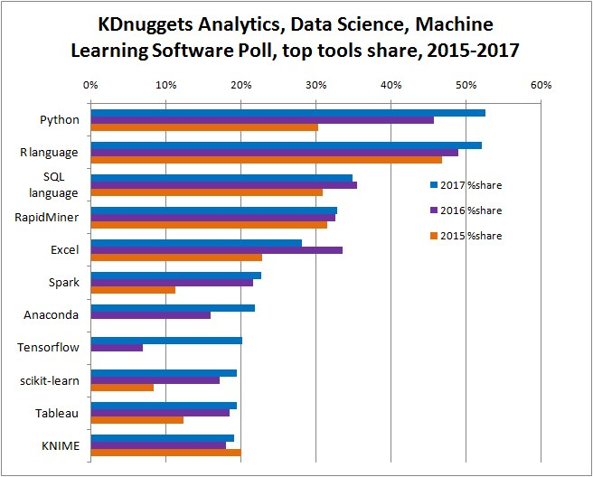

Para eso han hecho incapie en la optimizacion de las estructuras de los datos más importantes para este tipo de tareas. Esto se ve reflejado en los paquetes mas utilizados en R.

[figure not shown]

## Para entender un poco R

> “To understand computations in R, two slogans are helpful:
> - Everything that exists is an object.
> - Everything that happens is a function call."

> — John Chambers

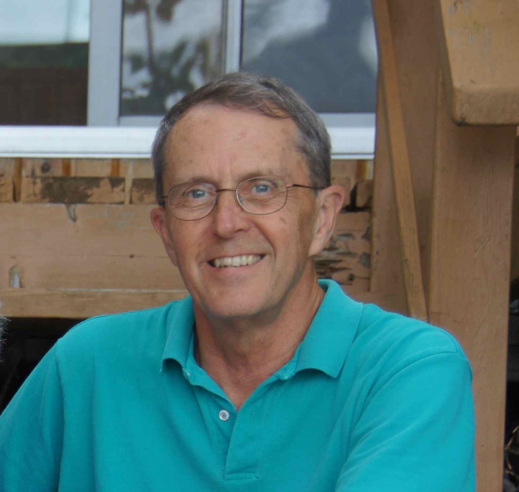

## Paradigmas

R es un lenguaje que al igual que Oz es multiparadigma, ya que soporta varios paradigmas, y el usuario puede utilizar el que le parezca más conveniente para resolver el problema. R soporta los paradigmas:

1. Funcional
2. Vectorial
3. Imperativo
4. Procedural
5. POO

## Tipado Dinámico

R es de tipado dinámico, con la particularidad de que al declarar una variable numérica automáticamente le asigna un double. Ser un lenguaje de tipado dinámico implica que una variable puede tomar cualquier valor, ya sea un entero, un flotante, un carácter en distintos momentos. A diferencia de un tipado estático donde hay que declarar de qué tipo va a ser la variable y este tipo es inalterable.Algunos lenguajes de tipado dinámico como R son, Python, Javascript o Oz, mientras que algunos de tipado estático pueden ser C o C++.

## Lenguaje Interpretado

R es un lenguaje de programación del tipo interpretado. Un lenguaje interpretado es aquel que ejecuta directamente instrucción a instrucción utilizando un interprete. Algunos ejemplos de otros lenguajes interpretados son Python, Javascript y R.

# Estructuras de control de flujo

Los bucles son un método de control de flujo para repetir una tarea o conjunto de tareas en un dominio. Un ejemplo para obtener la suma acumulativa de un vector de valores en R utilizando un bucle for es:

```r
  x <- 1:4
  acumulative_sum <- 0
  for (i in x){
    acumulative_sum <- acumulative_sum + x[i]
  }
  acumulative_sum
```

```
## [1] 10
```

```r
  x <- 1
  while(x < 5)  {
    x <- x+1;
    print(x);
  }
```

```
## [1] 2
## [1] 3
## [1] 4
## [1] 5
```

Finalmente existe el bucle repeat, el cual itera sobre una porción de código hasta encontrarse con un break. En el siguiente ejemplo se muestra como imprime nuevamente un vector de 5 elementos, pero esta vez utilizando repeat :

```r
  x <- 1
  repeat {
    print(x)
    x = x+1
    if (x == 6){
      break
    }
  }
```

```
## [1] 1
## [1] 2
## [1] 3
## [1] 4
## [1] 5
```

# Estructuras de datos

## Vectores

Hay muchos tipos de datos, en este caso vamos a hacer incapie en uno de los más importantes y abarcativos que son los vectores

Los vectores vienen en dos grandes grupos: vectores atómicos y listas. Difieren en términos de los tipos de sus elementos: para los vectores atómicos, todos los elementos deben tener el mismo tipo; para las listas, los elementos pueden tener diferentes tipos.

Si bien no es un vector, `NULL` está estrechamente relacionado con los vectores y, a menudo, cumple la función de un vector genérico de longitud cero. Este diagrama, que ampliaremos a lo largo de este capítulo, ilustra las relaciones básicas.

## Vectores Atomicos

Hay cuatro tipos principales de vectores atómicos: lógico, entero, doble y carácter (que contiene cadenas).

Aquí se puede apreciar claramente los diferentes tipos:

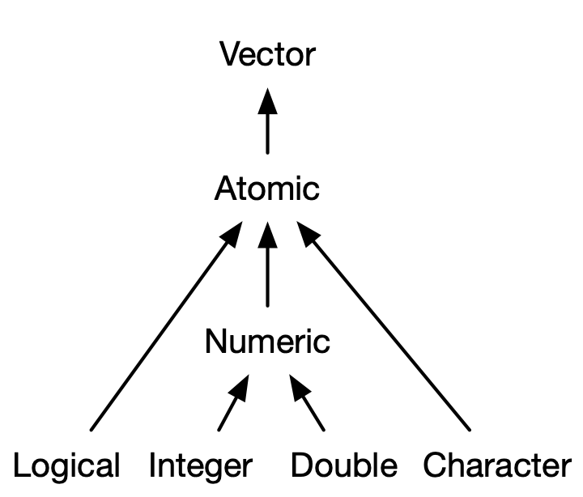

## Escalares

Un escalar es una constante o variable que contiene un dato atómico y unidimensional. Cada uno de los cuatro tipos principales tiene una sintaxis especial para crear un valor individual.

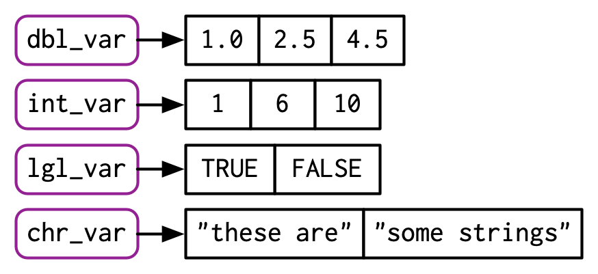

Ejemplo de como inicializar un vector:

```r
x <- c(1,2,3,4)
```

## Valores perdidos

R representa valores perdidos o desconocidos, con un valor centinela especial: `NA` (abreviatura de no aplicable). Los valores perdidos tienden a ser infecciosos: la mayoría de los cálculos que involucran un valor perdido devolverán otro valor perdido.

```r
NA > 5
```

```
## [1] NA
```

```
#> [1] NA
```

```r
10 * NA
```

```
## [1] NA
```

```
#> [1] NA
```

```r
!NA
```

```
## [1] NA
```

```
#> [1] NA
```

## Atributos

Los vectores atómicos no incluyen una serie de estructuras de datos importantes como matrices, arreglos o date-times. Estos tipos se construyen sobre los vectores atómicos al agregar atributos. Los atributos generalmente deben considerarse efímeros. Por ejemplo, la mayoría de las operaciones pierden la mayoría de los atributos. Solo hay dos atributos que se conservan habitualmente:

- **nombres** , un vector de caracteres que le da un nombre a cada elemento.
- **dim** , abreviatura de dimensiones, un vector entero, utilizado para convertir vectores en matrices.

### Nombres

Se puede nombrar un vector de tres maneras:

```r
  x <- c(a = 1, b = 2, c = 3)

  x <- 1:3
  names(x) <- c("a", "b", "c")

  x <- setNames(1:3, c("a", "b", "c"))
```

### Dimensiones

Se puede agregar un atributo `dim` a un vector. Esto le permite comportarse como una matriz bidimensional o un arreglo multidimensional. Las matrices y los arreglos son principalmente herramientas matemáticas y estadísticas, las cuales se utilizan en gran medida en estos lenguajes.

```r
  a <- matrix(1:6, nrow = 2, ncol = 3)

  b <- array(1:12, c(2, 3, 2))

  c <- 1:6
  dim(c) <- c(3, 2)
```